# Uso de la api del Covid-19 con pandas

Base de datos de interés, como URL y en formato JSON: http://api.covid19api.com/countries

## Instalamos las librerías con las que trabajararemos

Instalamos pandas con el siguiente comando:

```python
!pip install pandas
```

## Configuración de pandas

### Ahora vamos a importar la librería "pandas" y la renombramos como "pd" para usarla en el notebook

```python
import pandas as pd
```

# Crear variable

### A continuación hemos creado una variable nueva que añade la base de datos que usaremos

```python
url = 'https://api.covid19api.com/countries'
```

# Crear Dataframe

### Creamos ahora una tabla de "pandas" usando el JSON de la base de datos

```python
df = pd.read_json(url)
```

Así se enseña la tabla:

```python
df
```

|  | Country | Slug | ISO2 |
| --- | --- | --- | --- |
| 0 | Chad | chad | TD |
| 1 | Guinea-Bissau | guinea-bissau | GW |
| 2 | Hong Kong, SAR China | hong-kong-sar-china | HK |
| 3 | New Caledonia | new-caledonia | NC |
| 4 | Nigeria | nigeria | NG |
| ... | ... | ... | ... |
| 243 | Pakistan | pakistan | PK |
| 244 | Algeria | algeria | DZ |
| 245 | Bermuda | bermuda | BM |
| 246 | Gambia | gambia | GM |
| 247 | Russian Federation | russia | RU |

248 rows × 3 columns

# Exploración de la tabla

Así mostramos las primeras entradas de la tabla (denominadas como cabecera o head de la data frame --la tabla--)

```python
df.head()
```

|  | Country | Slug | ISO2 |
| --- | --- | --- | --- |
| 0 | Chad | chad | TD |
| 1 | Guinea-Bissau | guinea-bissau | GW |
| 2 | Hong Kong, SAR China | hong-kong-sar-china | HK |
| 3 | New Caledonia | new-caledonia | NC |
| 4 | Nigeria | nigeria | NG |

```python
df.head(6)
```

|  | Country | Slug | ISO2 |
| --- | --- | --- | --- |
| 0 | Chad | chad | TD |
| 1 | Guinea-Bissau | guinea-bissau | GW |
| 2 | Hong Kong, SAR China | hong-kong-sar-china | HK |
| 3 | New Caledonia | new-caledonia | NC |
| 4 | Nigeria | nigeria | NG |
| 5 | Sierra Leone | sierra-leone | SL |

```python
df.tail()
```

|  | Country | Slug | ISO2 |
| --- | --- | --- | --- |
| 243 | Pakistan | pakistan | PK |
| 244 | Algeria | algeria | DZ |
| 245 | Bermuda | bermuda | BM |
| 246 | Gambia | gambia | GM |
| 247 | Russian Federation | russia | RU |

Así mostramos las últimas entradas de la tabla (denominadas como tail). El número 2 indica cuántas filas mostramos

```python
df.tail(2)
```

|  | Country | Slug | ISO2 |
| --- | --- | --- | --- |
| 246 | Gambia | gambia | GM |
| 247 | Russian Federation | russia | RU |

Ahora enseñamos la información de la data frame como parte de la librería pandas

Enseña la información sobre el dataframe en la que incluye el índice (RangeIndex) con el número de entradas, el número de columnas que hay (Data Columns), el nombre de las columnas (Colum), la cantidad de datos nulos que posee la tabla (Non-Null Count), el tipo de variable de las columnas (Dtype) y el tamaño (memory usage)

```python
df.info()
```

```
<class 'pandas.core.frame.DataFrame'>
RangeIndex: 248 entries, 0 to 247
Data columns (total 3 columns):
 #   Column   Non-Null Count  Dtype
---  ------   --------------  -----
 0   Country  248 non-null    object
 1   Slug     248 non-null    object
 2   ISO2     248 non-null    object
dtypes: object(3)
memory usage: 5.9+ KB
```

Así se enseña la columna "country"

```python
df['Country']
```

```
0                      Chad
1             Guinea-Bissau
2      Hong Kong, SAR China
3             New Caledonia
4                   Nigeria
               ...
243                Pakistan
244                 Algeria
245                 Bermuda
246                  Gambia
247      Russian Federation
Name: Country, Length: 248, dtype: object
```

Así se enseña la fila 66 de la columna Country

```python
df['Country'][66]
```

```
'Republic of Kosovo'
```

# Tiempo real

Definimos las variables "url_es", "df_es", "df_es" a través de sus iguales y mostramos la variable recién definida "df_es" (tabla) Los datos los sacamos de esta URL:https://api.covid19api.com/country/spain/status/confirmed/live

```python
url_es = 'https://api.covid19api.com/country/spain/status/confirmed/live'
df_es = pd.read_json(url_es)
df_es
```

|  | Country | CountryCode | Province | City | CityCode | Lat | Lon | Cases | Status | Date |
| --- | --- | --- | --- | --- | --- | --- | --- | --- | --- | --- |
| 0 | Spain | ES |  |  |  | 40.46 | -3.75 | 0 | confirmed | 2020-01-22 00:00:00+00:00 |
| 1 | Spain | ES |  |  |  | 40.46 | -3.75 | 0 | confirmed | 2020-01-23 00:00:00+00:00 |
| 2 | Spain | ES |  |  |  | 40.46 | -3.75 | 0 | confirmed | 2020-01-24 00:00:00+00:00 |
| 3 | Spain | ES |  |  |  | 40.46 | -3.75 | 0 | confirmed | 2020-01-25 00:00:00+00:00 |
| 4 | Spain | ES |  |  |  | 40.46 | -3.75 | 0 | confirmed | 2020-01-26 00:00:00+00:00 |
| ... | ... | ... | ... | ... | ... | ... | ... | ... | ... | ... |
| 815 | Spain | ES |  |  |  | 40.46 | -3.75 | 11662214 | confirmed | 2022-04-16 00:00:00+00:00 |
| 816 | Spain | ES |  |  |  | 40.46 | -3.75 | 11662214 | confirmed | 2022-04-17 00:00:00+00:00 |
| 817 | Spain | ES |  |  |  | 40.46 | -3.75 | 11662214 | confirmed | 2022-04-18 00:00:00+00:00 |
| 818 | Spain | ES |  |  |  | 40.46 | -3.75 | 11736893 | confirmed | 2022-04-19 00:00:00+00:00 |
| 819 | Spain | ES |  |  |  | 40.46 | -3.75 | 11736893 | confirmed | 2022-04-20 00:00:00+00:00 |

820 rows × 10 columns

Enseñamos los nombres de las columnas de la tabla (df_es.columns)

```python
df_es.columns
```

```
Index(['Country', 'CountryCode', 'Province', 'City', 'CityCode', 'Lat', 'Lon',
       'Cases', 'Status', 'Date'],
      dtype='object')
```

Enseñamos la (0) primera fila por la cabecera de la columna "Date" de la tabla

```python
df_es['Date'].head(1)
```

```
0   2020-01-22 00:00:00+00:00
Name: Date, dtype: datetime64[ns, UTC]
```

Enseñamos la última fila (tail) de la tabla (819)

```python
df_es['Date'].tail(1)
```

```
819   2022-04-20 00:00:00+00:00
Name: Date, dtype: datetime64[ns, UTC]
```

Enseñamos la información sobre la tabla en la que se incluye el índice, el número de columnas, el nombre de las columnas (Colum), la cantidad de datos nulos que posee la tabla (Non-Null Count), el tipo de variable de las columnas (Dtype) y el tamaño (memory usage)

```python
df_es.info()
```

```
<class 'pandas.core.frame.DataFrame'>
RangeIndex: 820 entries, 0 to 819
Data columns (total 10 columns):
 #   Column       Non-Null Count  Dtype
---  ------       --------------  -----
 0   Country      820 non-null    object
 1   CountryCode  820 non-null    object
 2   Province     820 non-null    object
 3   City         820 non-null    object
 4   CityCode     820 non-null    object
 5   Lat          820 non-null    float64
 6   Lon          820 non-null    float64
 7   Cases        820 non-null    int64
 8   Status       820 non-null    object
 9   Date         820 non-null    datetime64[ns, UTC]
dtypes: datetime64[ns, UTC](1), float64(2), int64(1), object(6)
memory usage: 64.2+ KB
```

Ahora enseñamos las variables estadísticas de la tabla

```python
df_es.describe()
```

|  | Lat | Lon | Cases |
| --- | --- | --- | --- |
| count | 8.200000e+02 | 820.00 | 8.200000e+02 |
| mean | 4.046000e+01 | -3.75 | 3.416380e+06 |
| std | 7.109764e-15 | 0.00 | 3.301819e+06 |
| min | 4.046000e+01 | -3.75 | 0.000000e+00 |
| 25% | 4.046000e+01 | -3.75 | 3.414432e+05 |
| 50% | 4.046000e+01 | -3.75 | 3.179284e+06 |
| 75% | 4.046000e+01 | -3.75 | 4.952212e+06 |
| max | 4.046000e+01 | -3.75 | 1.173689e+07 |

Enseñamos la tabla en sí

```python
df_es
```

|  | Country | CountryCode | Province | City | CityCode | Lat | Lon | Cases | Status | Date |
| --- | --- | --- | --- | --- | --- | --- | --- | --- | --- | --- |
| 0 | Spain | ES |  |  |  | 40.46 | -3.75 | 0 | confirmed | 2020-01-22 00:00:00+00:00 |
| 1 | Spain | ES |  |  |  | 40.46 | -3.75 | 0 | confirmed | 2020-01-23 00:00:00+00:00 |
| 2 | Spain | ES |  |  |  | 40.46 | -3.75 | 0 | confirmed | 2020-01-24 00:00:00+00:00 |
| 3 | Spain | ES |  |  |  | 40.46 | -3.75 | 0 | confirmed | 2020-01-25 00:00:00+00:00 |
| 4 | Spain | ES |  |  |  | 40.46 | -3.75 | 0 | confirmed | 2020-01-26 00:00:00+00:00 |
| ... | ... | ... | ... | ... | ... | ... | ... | ... | ... | ... |
| 815 | Spain | ES |  |  |  | 40.46 | -3.75 | 11662214 | confirmed | 2022-04-16 00:00:00+00:00 |
| 816 | Spain | ES |  |  |  | 40.46 | -3.75 | 11662214 | confirmed | 2022-04-17 00:00:00+00:00 |
| 817 | Spain | ES |  |  |  | 40.46 | -3.75 | 11662214 | confirmed | 2022-04-18 00:00:00+00:00 |
| 818 | Spain | ES |  |  |  | 40.46 | -3.75 | 11736893 | confirmed | 2022-04-19 00:00:00+00:00 |
| 819 | Spain | ES |  |  |  | 40.46 | -3.75 | 11736893 | confirmed | 2022-04-20 00:00:00+00:00 |

820 rows × 10 columns

Enseñamos la tabla en referencia a la columna denominada "Date"

```python
df_es.set_index('Date')
```

| Date | Country | CountryCode | Province | City | CityCode | Lat | Lon | Cases | Status |
| --- | --- | --- | --- | --- | --- | --- | --- | --- | --- |
| 2020-01-22 00:00:00+00:00 | Spain | ES |  |  |  | 40.46 | -3.75 | 0 | confirmed |
| 2020-01-23 00:00:00+00:00 | Spain | ES |  |  |  | 40.46 | -3.75 | 0 | confirmed |
| 2020-01-24 00:00:00+00:00 | Spain | ES |  |  |  | 40.46 | -3.75 | 0 | confirmed |
| 2020-01-25 00:00:00+00:00 | Spain | ES |  |  |  | 40.46 | -3.75 | 0 | confirmed |
| 2020-01-26 00:00:00+00:00 | Spain | ES |  |  |  | 40.46 | -3.75 | 0 | confirmed |
| ... | ... | ... | ... | ... | ... | ... | ... | ... | ... |
| 2022-04-16 00:00:00+00:00 | Spain | ES |  |  |  | 40.46 | -3.75 | 11662214 | confirmed |
| 2022-04-17 00:00:00+00:00 | Spain | ES |  |  |  | 40.46 | -3.75 | 11662214 | confirmed |
| 2022-04-18 00:00:00+00:00 | Spain | ES |  |  |  | 40.46 | -3.75 | 11662214 | confirmed |
| 2022-04-19 00:00:00+00:00 | Spain | ES |  |  |  | 40.46 | -3.75 | 11736893 | confirmed |
| 2022-04-20 00:00:00+00:00 | Spain | ES |  |  |  | 40.46 | -3.75 | 11736893 | confirmed |

820 rows × 9 columns

Enseña la columna de los casos (cases) cuando hemos ordenado la tabla por date. Es decir, primero sale la fecha y después el número de casos.

```python
df_es.set_index('Date')['Cases']
```

```
Date
2020-01-22 00:00:00+00:00           0
2020-01-23 00:00:00+00:00           0
2020-01-24 00:00:00+00:00           0
2020-01-25 00:00:00+00:00           0
2020-01-26 00:00:00+00:00           0
                               ...
2022-04-16 00:00:00+00:00    11662214
2022-04-17 00:00:00+00:00    11662214
2022-04-18 00:00:00+00:00    11662214
2022-04-19 00:00:00+00:00    11736893
2022-04-20 00:00:00+00:00    11736893
Name: Cases, Length: 820, dtype: int64
```

Damos título (a través de title) al gráfico recién creado (a través de .plot)

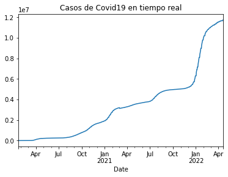

```python
df_es.set_index('Date')['Cases'].plot(title="Casos de Covid19 en tiempo real")
```

# Otro país

Damos nombre a las variables (las definimos) y mostramos y creamos el gráfico df_it.set_index('Date')['Cases'].plot()df_it.set_index('Date')['Cases'].plot()

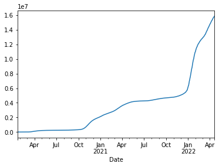

```python
url_it = 'https://api.covid19api.com/country/italy/status/confirmed/live'
df_it = pd.read_json(url_it)
df_it.set_index('Date')['Cases'].plot()
```

# Comparación

Definimos las variables

```python
casos_es = df_es.set_index('Date')['Cases']
casos_it = df_it.set_index('Date')['Cases']
```

Concatenamos los casos de los dos países en una misma tabla (a través del uso de concat)

```python
vs = pd.concat([casos_it,casos_es],axis=1)
vs
```

| Date | Cases | Cases |
| --- | --- | --- |
| 2020-01-22 00:00:00+00:00 | 0 | 0 |
| 2020-01-23 00:00:00+00:00 | 0 | 0 |
| 2020-01-24 00:00:00+00:00 | 0 | 0 |
| 2020-01-25 00:00:00+00:00 | 0 | 0 |
| 2020-01-26 00:00:00+00:00 | 0 | 0 |
| ... | ... | ... |
| 2022-04-16 00:00:00+00:00 | 15659835 | 11662214 |
| 2022-04-17 00:00:00+00:00 | 15712088 | 11662214 |
| 2022-04-18 00:00:00+00:00 | 15730676 | 11662214 |
| 2022-04-19 00:00:00+00:00 | 15758002 | 11736893 |
| 2022-04-20 00:00:00+00:00 | 15858442 | 11736893 |

820 rows × 2 columns

Creamos el gráfico a y damos nombre a las variables

[figure not shown]

```python
vs.columns =['España','Italia']
vs.plot(title="España vs Italia")
```

Guardamos en un csv (un tipo de archivo)

```python
vs.to_csv('esvit.csv')
```

Comprobamos que el archivo se ha creado y vemos lo que contiene nuestro Jupyter

```python
!ls
```

```
 esvit.csv			   python-pruebas.ipynb   Untitled.ipynb
'Prueba 2 en R.ipynb'		   seaborn-data
 python-api-covid19-pandas.ipynb   Shared_Resources
```

Importamos los datos como plt y guardamos el gráfico --> No sé lo que es un plt

[figure not shown]

```python
import matplotlib.pyplot as plt
vs.plot()
plt.savefig ('escit.png')
```